# Author classification using tree-based methods, SVMs, KNN, and neural networks

Joe Connelly, Sean Duan & David Reynolds

## Introduction

The dataset analyzed in this report is a subset of data taken from a dataset that includes information about books, with each row representing a different book. The features, which are unnamed, are several objective numeric measures of a text, and the goal of this analysis is to identify the correct author of each book. There are nine different authors (i.e., response levels) and 10 features. The training set contains 10,000 books, and the test set contains 5,000 books. Cross-entropy was used to evaluate model performance.

Given that we have very little information about the predictors and that the number of predictors is significantly lower than the number of observations, we decided that a tree-based method, an SVM, a KNN classifier, and a neural network was a good range of models to consider. Linear discriminant analysis, quadratic discriminant analysis, and multinomial logistic regression were also considered, but these methods did not perform as well, and therefore they will not be discussed.

Since the data contains no missing values, no imputation was necessary. However, it was ensured that the response was correctly assigned as a factor rather than a continuous numeric variable. All other preprocessing steps are explained in the model descriptions.

## Basic data analysis/description/plots

Variables 6 and 10 appeared to be highly correlated with one another, but we decided not to remove them, as there are only 10 predictors. Variables 1, 2, 5, and 7 are highly skewed, which may pose a challenge. The fact that there are no categorical predictors should help. Overall, we did not feel that any modifications needed to be made to the data before modeling.

## Tree-based methods

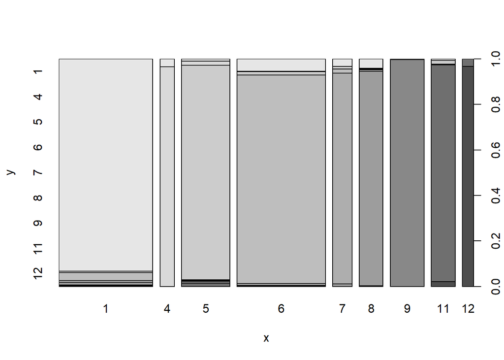

```
##             1         4         5         6         7          8        9
## V1  174.87608 167.66889 260.00498 163.73950  94.03984 106.901193 69.30143
## V2   89.93451  82.16487 103.99710 157.66299 177.25185 149.744469 47.42813
## V3   87.46506  89.61181 113.86956 134.16147  83.72335 106.232098 38.40002
## V4   83.75233  55.29248  91.63106 107.99495  61.58406  51.802509 27.46787
## V5  144.02253 112.73041 115.76807 122.07737  61.60680  82.421268 94.10189
## V6   51.70028  18.09672  18.60271  43.74142  22.11435  36.191195 30.37883
## V7   19.35715  11.18891  21.26381  20.10700  17.45872   5.825871 20.15298
## V8   40.07680  10.20625  27.08201  35.98214  20.69224  22.821483 13.87722
## V9  101.79006  55.61267  74.00607 178.75079  30.67687  51.715291 38.41430
## V10  19.38636  13.25005  22.64811  25.79491  29.79219  31.050128  7.48118
##             11         12 MeanDecreaseAccuracy MeanDecreaseGini
## V1   84.105937 68.5610752            330.70584         689.3960
## V2   49.975882 48.5639720            219.92341         614.8139
## V3   38.241486 49.9489870            190.81982         577.9205
## V4   58.972815 31.6274904            144.38852         462.5310
## V5   69.202971 99.0971950            212.71529         811.7678
## V6   16.178960 -0.9783089             72.14533         159.3603
## V7   12.425447 14.6802125             39.41259         105.5206
## V8    8.427058  7.0029028             65.62250         143.0998
## V9  125.325555 32.2993788            243.91767         471.2158
## V10  10.234106 12.7175464             51.67774         110.9325
```

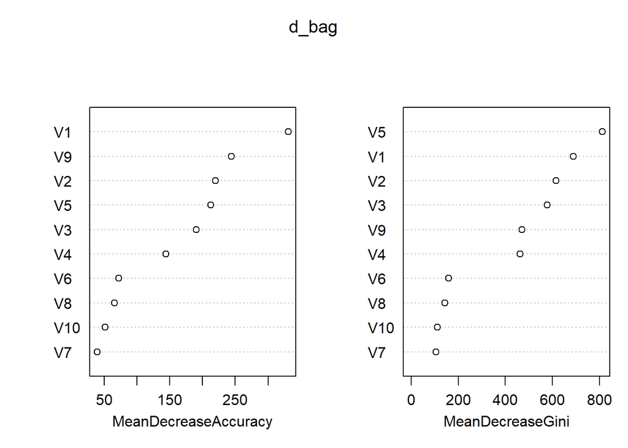

We initially considered tree based methods because if we look at large trees using tree aggregation methods (bagging, boosting, random forest, etc.) we should be well insulated against the effects of overfitting. Especially given that we have no context regarding what the specific application of this data is, making sure that we don’t overfit is especially important. Additionally, the value we can obtain from plots of variable importance and node purity importance will allow us to make additional inferences on the dataset.

We looked at several different types of tree-based methods. Initially, we considered a plain CART, bagging, boosting, and random forest. For each of these methods, we proceeded to do hold-out testing on a subset of the training data, using classification error rate as our criteria. After tuning all of our tree-based methods using this criteria, we selected the best tree-based method, which here was bagging.

## Support vector machines

We initially thought of using an SVM as a classification model for this project for a couple of reasons. From what we learned in class, SVC and SVMs seem to be able to fit pretty complex data, and with us knowing really nothing about the data at all, we thought that it would be interesting to see if a more complex model would work best. Another reason we wanted to use the SVM modeling techniques was because of the usefulness in tuning the parameters. Because of how easy it is to tune the parameters, we were able to try and fit many different SVCs and SVMs.

Using classification error rate as the criteria, we were able to come up with the best model in predicting the training set. Unfortunately, none of the models tested had a training error rate that was lower than 17 percent. So, our next task was to use cross entropy to tune the parameters. We used the models that were tuned based on misclassification rates as approximations and then plugged and chugged to find the best model in terms of cross-entropy. The best model was a polynomial kernel model with a cost of .0001 and degree of 3.

## KNN

KNN was considered because it is very flexible and the bias/variance tradeoff can be controlled directly by varying K. The decision boundary is likely highly nonlinear since there are multiple classes in the response, so KNN is probably better to consider for this problem than LDA, QDA, or multinomial logistic regression.

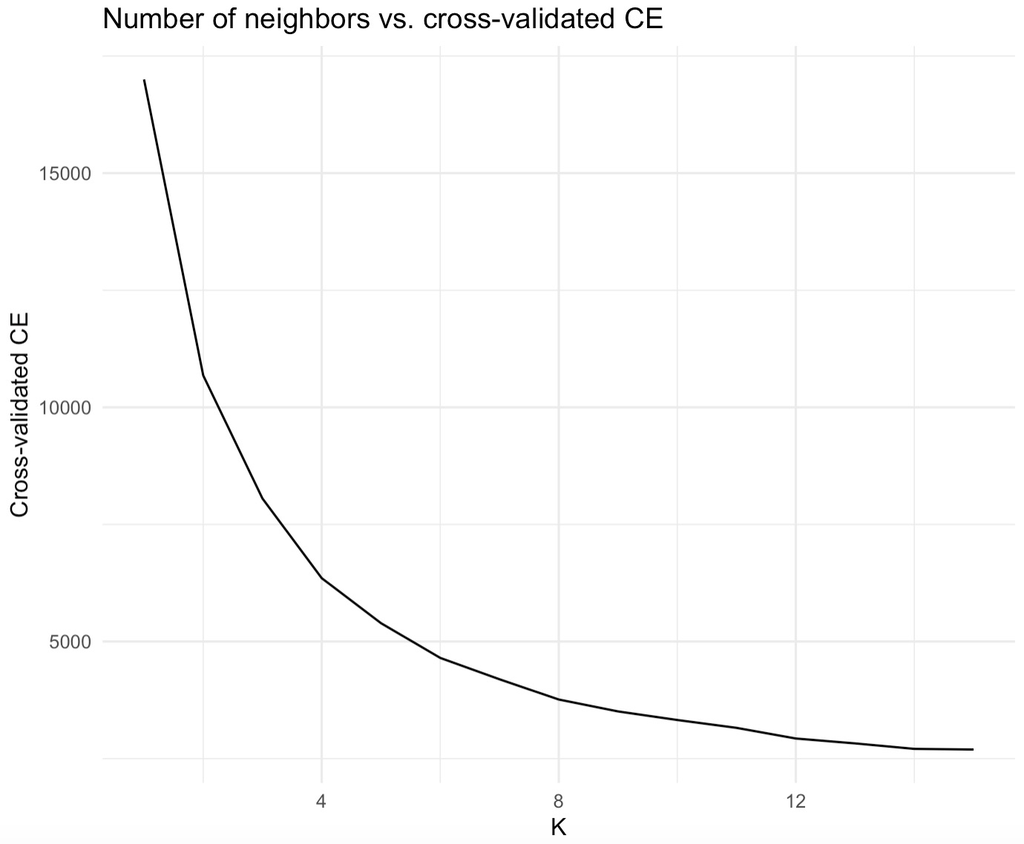

## Neural network

A neural network was considered because it is a very flexible and widely used machine learning algorithm. It is very good at modeling nonlinear relationships, and it is likely that the decision boundary in this problem is not linear.

Before training the neural network, the predictors in the training and test sets were scaled to be between 0 and 1. The parameters were tuned using five-fold cross-validated cross-entropy. In other words, the training data was split into five folds and the average cross-entropy was computed after the neural network was fit five times. This was performed for a range of parameter values.

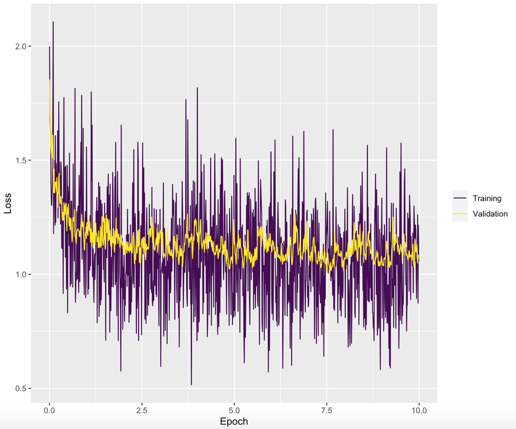

Ppred1.RData is the prediction matrix for bagging, Ppred2.RData is the matrix for SVM, Pred3.RData is the matrix for KNN, and Ppred4.RData is the matrix for the neural network. All four methods performed fairly well on the training set, but it is of course difficult to evaluate performance without test labels. Cross-validated cross-entropy was used to train the KNN classifier and neural network, which may be the best method available to evaluate model performance for this particular problem. In the future, it would probably be useful to find better ways to tune parameters while maintaining computational speed. It can be difficult to train some of these models, especially neural networks, with low computing power.